# Piloting Graph Learning in Children

```r
library(summarytools, quietly = TRUE)
library(dplyr, quietly = TRUE)
logdir='/Users/utooley/Dropbox/projects/in_progress/network_learning/code/netlearn_kids_v1/logs/'
datadir='~/Dropbox/projects/in_progress/network_learning/code/netlearn_kids_v1/subjData/'
exposureData <- read.delim(paste0(logdir, "CNL002/CNL002_log_run1.csv"))
seqcmplData <- read.csv(paste0(datadir, "CNL002/seqcmpl/CNL002_log_seqcmpl.csv"))
#omotData<- read.csv(paste0(datadir, "CNL002/OMOT/CNL002_log_omot.csv"))
dyadicData<- read.csv(paste0(datadir, "CNL002/dyad_choice/CNL002_log_dyad_choice.csv"))
seqcmplData$correct <- factor(seqcmplData$correct, ordered=TRUE, labels=c("Incorrect", "Correct"))
exposureData$rt <- as.numeric(as.character(exposureData$rt))
```

## Check each assessment for data quality

```r
view(dfSummary(exposureData))
view(dfSummary(seqcmplData))
view(dfSummary(omotData))
summary(exposureData$rt)
```

```
   Min. 1st Qu.  Median    Mean 3rd Qu.    Max.
0.01068 1.55090 2.31546 2.80500 3.56738 8.65142
```

**Does RT go down or up as the task goes on?**

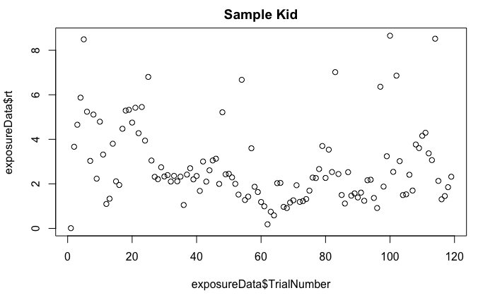

```r
plot(exposureData$TrialNumber, exposureData$rt, main="Sample Kid")
```

```r
cor.test(exposureData$TrialNumber, exposureData$rt)
```

```
    Pearson's product-moment correlation

data:  exposureData$TrialNumber and exposureData$rt
t = -1.7507, df = 117, p-value = 0.08261
alternative hypothesis: true correlation is not equal to 0
95 percent confidence interval:
 -0.33027277  0.02081878
sample estimates:
       cor
-0.1597755
```

**Is RT longer after transition nodes?**

```r
exposureData$transition_node <- ifelse((exposureData$node1==4 & exposureData$node2 ==5) |(exposureData$node1 ==5 & exposureData$node2 ==4), 1, 0)
exposureData$transition_node <- factor(exposureData$transition_node, labels=c("No", "Yes"))
exposureData %>%  group_by(transition_node) %>% summarise(avg_rt=mean(rt), med_rt=median(rt), std_dev=sd(rt), n_trials=n())
```

| transition_node | avg_rt | med_rt | std_dev | n_trials |
| --- | --- | --- | --- | --- |
| No | 2.773869 | 2.315455 | 1.713370 | 109 |
| Yes | 3.144383 | 2.650195 | 2.327652 | 10 |

Yes.

**How long does it take with 125 nodes (of which 4 are practice trials)?**

```r
max(exposureData$onset)/60
```

```
[1] 9.191564
```

## Sequence Completion Task

```r
table(seqcmplData$correct)
```

```
Incorrect   Correct
        4         4
```

## Odd Man Out Task-Did not do

```r
view(dfSummary(omotData))
```

Does average number correct differ by trial type?

```r
omotData %>% group_by(trial_type) %>% summarise(avg_correct=mean(correct))
```

**Does RT differ by trial type?**

```r
omotData %>% group_by(trial_type) %>% summarise(avg_rt=mean(rt), med_rt=median(rt), std_dev=sd(rt), n_trials=n())
```

**Does RT differ by sequence-longer later in the sequence, or shorter?**

```r
cor.test(omotData$TrialNumber, omotData$rt)
```

# Subject 2

```r
exposureData <- read.delim(paste0(logdir, "NL002/NL002_log_run1.csv"))
seqcmplData <- read.csv(paste0(datadir, "NL002/seqcmpl/NL002_log_seqcmpl.csv"))
omotData<- read.csv(paste0(datadir, "NL002/OMOT/NL002_log_omot.csv"))
#seqcmplData$correct <- factor(seqcmplData$correct, ordered=TRUE, levels=c(1,0), labels=c("Incorrect", "Correct"))
#omotData$correct <- factor(omotData$correct, ordered=TRUE, labels=c("Incorrect", "Correct")) #commented out because if make them factors then can't do proportion calculations on them.
```

## Check exposure data quality

```r
view(dfSummary(exposureData))
summary(exposureData$rt)
```

**Does RT go down or up as the task goes on?**

```r
plot(exposureData$TrialNumber, exposureData$rt)
cor.test(exposureData$TrialNumber, exposureData$rt)
```

[output not shown]

It goes down (not surprisingly)!

**Is RT longer after transition nodes?**

```r
exposureData$transition_node <- ifelse((exposureData$node1==4 & exposureData$node2 ==5) |(exposureData$node1 ==5 & exposureData$node2 ==4), 1, 0)
exposureData$transition_node <- factor(exposureData$transition_node, labels=c("No", "Yes"))
exposureData %>%  group_by(transition_node) %>% summarise(avg_rt=mean(rt), med_rt=median(rt), std_dev=sd(rt), n_trials=n())
```

[output not shown]

Yes, it is!

**How long does it take with 200 nodes?**

```r
max(exposureData$onset)/60
```

[output not shown]

## Sequence Completion Task

Data quality

```r
view(dfSummary(seqcmplData))
```

How many are correct? 100%

```r
table(seqcmplData$correct)
```

[output not shown]

## Odd Man Out Task

```r
view(dfSummary(omotData))
```

On average, 58% correct on OMOT.

Does average number correct differ by trial type?

```r
omotData %>% group_by(trial_type) %>% summarise(avg_correct=mean(correct))
```

[output not shown]

The ‘correct’ answer for catch trials is the node that is 2 edges away rather than one edge away, but they are within the same community. 44% is still above chance on the non-conservative trials!

**Does RT differ by trial type?**

```r
omotData %>% group_by(trial_type) %>% summarise(avg_rt=mean(rt), med_rt=median(rt), std_dev=sd(rt), n_trials=n())
```

[output not shown]

Average and median RT is highest in non-conservative trials, lowest in conservative trials, as we would expect.

**Does RT differ by sequence-longer later in the sequence, or shorter?**

```r
cor.test(omotData$TrialNumber, omotData$rt)
```

[output not shown]

Not strongly so.

## Conclusions

Did better than expected on sequence completion–100% accuracy on sequence completion. 75% accuracy on OMOT catch trials, 61% on conservative trials and 44% on non-conservative trials (still above chance at 33%), RT on OMOT looks as we might expect, lowest for conservative trials, highest on non-conservative trials. Took 13 min with 200 nodes. Should I make it shorter, still? RT is longer on transition nodes (4 to 5 or 5 to 4).

# Subject 3

```r
exposureData <- read.delim(paste0(logdir, "NL003/NL003_log_run1.csv"))
seqcmplData <- read.csv(paste0(datadir, "NL003/seqcmpl/NL003_log_seqcmpl.csv"))
omotData<- read.csv(paste0(datadir, "NL003/OMOT/NL003_log_omot.csv"))
#seqcmplData$correct <- factor(seqcmplData$correct, ordered=TRUE, levels=c(1,0), labels=c("Incorrect", "Correct"))
#omotData$correct <- factor(omotData$correct, ordered=TRUE, labels=c("Incorrect", "Correct")) #commented out because if make them factors then can't do proportion calculations on them.
```

## Check exposure data quality

```r
view(dfSummary(exposureData))
summary(exposureData$rt)
```

**Does RT go down or up as the task goes on?**

```r
plot(exposureData$TrialNumber, exposureData$rt)
cor.test(exposureData$TrialNumber, exposureData$rt)
```

[output not shown]

It goes down (not surprisingly)! **Is RT longer after transition nodes?**

```r
exposureData$transition_node <- ifelse((exposureData$node1==4 & exposureData$node2 ==5) |(exposureData$node1 ==5 & exposureData$node2 ==4), 1, 0)
exposureData$transition_node <- factor(exposureData$transition_node, labels=c("No", "Yes"))
exposureData %>%  group_by(transition_node) %>% summarise(avg_rt=mean(rt), med_rt=median(rt), std_dev=sd(rt), n_trials=n())
```

[output not shown]

No, it’s not.

**How long does it take with 200 nodes?**

```r
max(exposureData$onset)/60
```

[output not shown]

## Sequence Completion Task

Data quality

```r
view(dfSummary(seqcmplData))
```

How many are correct? 88%.

```r
table(seqcmplData$correct)
```

[output not shown]

## Odd Man Out Task

```r
view(dfSummary(omotData))
```

100% correct on OMOT!

Does average number correct differ by trial type?

```r
omotData %>% group_by(trial_type) %>% summarise(avg_correct=mean(correct))
```

[output not shown]

NO difference.

**Does RT differ by trial type?**

```r
omotData %>% group_by(trial_type) %>% summarise(avg_rt=mean(rt), med_rt=median(rt), std_dev=sd(rt), n_trials=n())
```

[output not shown]

Average and median RT is highest in catch trials, lowest in conservative trials.

**Does RT differ by sequence-longer later in the sequence, or shorter?**

```r
cor.test(omotData$TrialNumber, omotData$rt)
```

[output not shown]

Not strongly so.

## Conclusions

Did better than expected! 88% accuracy on sequence completion and 100% accuracy on the OMOT. RT on OMOT looks as we might expect, lowest for conservative trials, highest on catch trials. Took 17 min with 200 nodes. Not enough variance? RT is not longer on transition nodes (4 to 5 or 5 to 4).